JOURNAL CLUB / SEPTEMBER 18, 2026

# Self-evolving agents

What experience makes possible

Experience → retained change → future work

Robert Yang · Fundamental Research Labs

Retain  
*what helps.*01 / EXPERIENCE02 / REVISE03 / REUSECONCEPTUAL LEARNING LOOP

SELF-EVOLVING AGENTSINTRODUCTION

## What should the agent do better next time?

Illustrative example · an agent reconciles a financial report, then receives a new company’s files.

### Save the useful check

Check units and reporting periods.  
Reconcile totals before writing.  
Record when those checks apply.

### See whether it helps again

New company: does the procedure help?  
Different task: should it be retrieved?  
Later updates: does it still work?

An agent learns from experience when a saved change improves what it does on later work.

SELF-EVOLVING AGENTSINTRODUCTION

## Learning new tasks also raises two different questions

The whole agent can learn through saved instructions, software changes, or model training.

### Can it keep learning?

Learn a new task without losing  
what worked on earlier tasks.  
This is continual learning.

### Can it learn to learn better?

Use experience to improve how  
it learns the next task.  
This is meta-learning.

These questions can overlap. A better learning method still needs to preserve earlier abilities.

SELF-EVOLVING AGENTSINTRODUCTION

## What can experience change?

A saved instruction can change the agent’s behavior even when the underlying model stays the same.

| What changes | Concrete example | How it helps later work |
| --- | --- | --- |
| Notes or reusable skills | Save a checklist for checking a report | Read and apply it on the next report |
| Prompts or agent software | Change when to call a tool or check an answer | Follow a better procedure next time |
| Model weights | Train on examples produced from experience | Use behavior learned through training |

The agent’s “harness” is the software that organizes its model calls, tools, and task execution.

SELF-EVOLVING AGENTSINTRODUCTION

THE MAIN QUESTION

## When does experience create a lasting advantage worth the cost?

Experience must add useful expertise, fit future work, and repay the effort of learning.

01 Add useful expertise · 02 Select and preserve it · 03 Learn to adapt

SELF-EVOLVING AGENTSRESULTS / USEFUL EXPERTISE

## WikiSkill keeps lessons from rejected changes

Record task attempts → collect lessons in a wiki → propose and test reusable instructions. A rejected change does not erase the wiki.

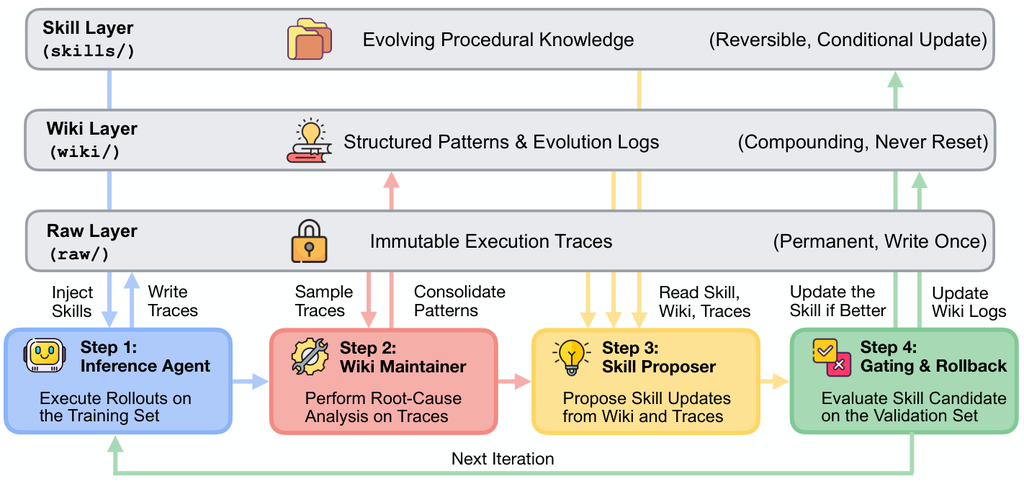

Original source · [Tang et al. · WikiSkill v1 · Figure 2, p. 4 · Complete diagram; caption omitted](https://arxiv.org/abs/2608.27454v1)

SELF-EVOLVING AGENTSRESULTS / USEFUL EXPERTISE

## WikiSkill’s learned instructions help on unseen tasks

WikiSkill · Qwen-3.5-9B · mean accuracy across five benchmarks

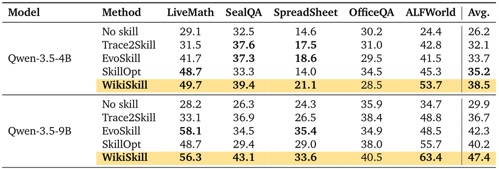

Original source · [Tang et al. · WikiSkill v1 · Table 1, p. 8 · Qwen 4B / 9B excerpt](https://arxiv.org/abs/2608.27454v1)

47.4%

Average accuracy: 29.9% without skills; 42.3% with EvoSkill; 47.4% with WikiSkill.

WikiSkill leads the strongest competing method here by 5.1 percentage points.

This compares complete methods, not the wiki alone. Skills are supplied directly; a smaller model worsens on one benchmark.

SELF-EVOLVING AGENTSRESULTS / USEFUL EXPERTISE

## Can one mistake teach the agent a reusable check?

FinEvo example · the agent writes a financial report, receives feedback, and saves instructions for later reports.

### A mistake in one report

The report says gross margin is 40.02%.  
Its own revenue and cost imply 41.00%.  
The judging model flags the error.

### A check for the next report

Recompute the margin from revenue and cost.  
Check the summary against the calculations.  
Save these instructions; keep model weights fixed.

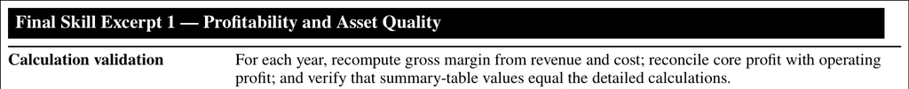

Original source · [Deng et al. · Figure 10, PDF p.21 · Saved instruction: calculation row; other rows omitted](https://arxiv.org/html/2608.06144v1)

This documents a saved correction. Whether it prevents later mistakes needs a separate test.

SELF-EVOLVING AGENTSRESULTS / USEFUL EXPERTISE

## Why learn the check if an expert could supply it?

FinEvo compares different ways to prepare the same agent for recurring financial work.

01

### Start fresh

Clear lessons between tasks. Each case starts without experience from earlier cases.

**What can the agent do on its own?**

02

### Give good instructions

Supply an expert procedure before the work begins. Keep it fixed throughout.

**What does good preparation buy?**

03

### Learn from feedback

After each case, revise reusable instructions for future cases.

**What extra benefit does learning buy?**

120 tasks, three shuffled orders. These are separate experimental conditions, not stages of one training run.

SELF-EVOLVING AGENTSRESULTS / USEFUL EXPERTISE

## Learning adds 7 points over expert instructions

FinEvo · average score out of 100 · one Claude Code setup using Qwen3.7-Max

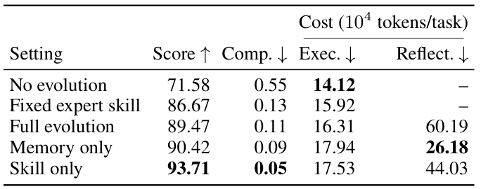

Original source · [Deng et al. · FinEvo-Bench v1 · Table 5, PDF p. 6 · Complete table](https://arxiv.org/html/2608.06144v1)

**Memory only**

Update stored notes.

**Skill only**

Update reusable procedure instructions.

**Full evolution**

Update both notes and procedures (89.47).

### Start fresh · 71.58

No saved lessons carry into the next case.

### Expert instructions · 86.67

A good procedure is supplied upfront.

### Learn instructions · 93.71

Best score here, with about 3.9× the recorded tokens of fixed instructions.

Learning: 616k tokens/task; fixed instructions: 159k. Judging and authoring excluded; variation across runs not reported.

SELF-EVOLVING AGENTSRESULTS / USEFUL EXPERTISE

## Could the same effort buy better answers directly?

Compare (a) trying several solutions with (c) spending attempts on changes to the agent’s software.

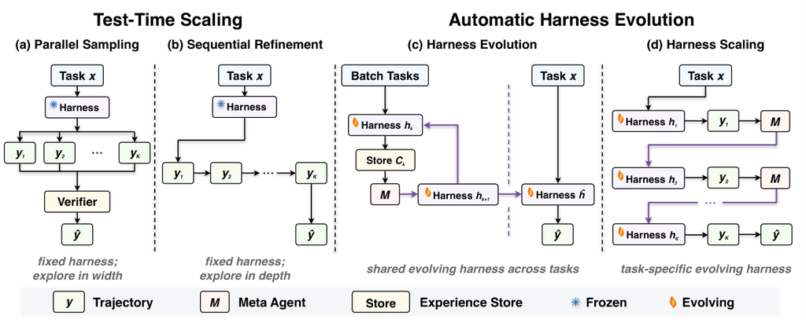

Original source · [Wang et al. · Harness evaluation v2 · Figure 2, p. 3 · All four panels and legend](https://arxiv.org/abs/2607.12227v2)

SELF-EVOLVING AGENTSRESULTS / USEFUL EXPERTISE

## In this test, trying more solutions beats revising the agent

Terminal-Bench · 89 tasks · five task attempts per method · no unit-test feedback

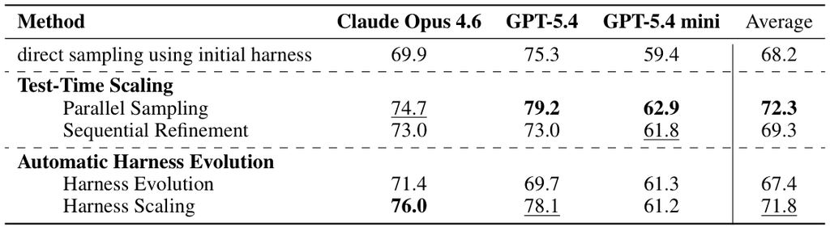

Original source · [Wang et al. · Harness evaluation v2 · Table 1, p. 6 · Complete table](https://arxiv.org/abs/2607.12227v2)

72.3 vs 67.4

Try several solutions: 72.3% success. Revise agent software: 67.4%.

On 34 new tasks: 68.3% with revised software versus 67.7% with the original.

Five attempts each does not match all costs. This tests one implementation; uncertainty intervals are absent.

SELF-EVOLVING AGENTSRESULTS / DURABILITY

RESULTS / 02

## Will earlier learning still help after more work?

Two things can go wrong: a saved lesson may not fit the next task, or learning something new may damage earlier knowledge.

AgentStream: does the lesson fit? SEAL: does earlier knowledge survive?

SELF-EVOLVING AGENTSRESULTS / DURABILITY

## Does memory still help when the work changes?

AgentStream tests 300 tasks across six domains, including coding and web research. Model weights stay fixed.

[figure not shown]

Original source · [AgentStream v1 · Fig. 1(b); baseline panel (a) omitted](https://arxiv.org/html/2608.00155v1)

**Learning loop**

Attempt a task → save notes or procedures → reuse them on later tasks.

**Comparison**

The same model, carrying no lessons between tasks.

### Isolated · separate histories

Each domain learns from its own tasks. Lessons stay within that domain.

### Sequential · shared history

Finish one domain, then start the next. Carry the saved lessons across.

### Interleaved · shared history

Mix tasks from different domains. Keep learning into one shared history.

Updates use execution results and self-reflection; correct-answer labels are withheld from the learning agent.

SELF-EVOLVING AGENTSRESULTS / DURABILITY

## The same memory method can help or hurt

Score change versus no retained lessons, in percentage points. Averages over three models and three task orders.

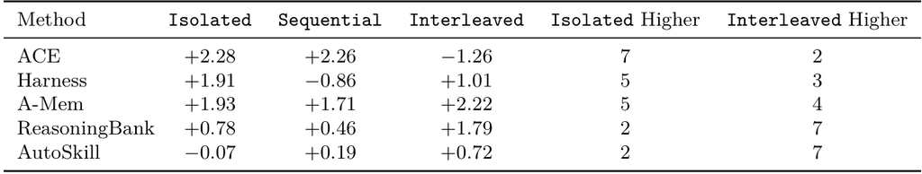

Original source · [AgentStream v1 · Table 5, p. 11 · Last columns: wins out of 9 model/order combinations; ties possible](https://arxiv.org/html/2608.00155v1)

Help → harm

ACE adds notes to the prompt: +2.28 separate; −1.26 mixed.

ReasoningBank retrieves selected notes: +0.78 → +1.79. Mixing can help too.

Methods differ in more than retrieval: this does not isolate why they behave differently. No confidence intervals reported.

SELF-EVOLVING AGENTSRESULTS / DURABILITY

## Can SEAL learn new facts without losing old ones?

SEAL (Self-Adapting LLMs) changes model weights. We will test new learning first, then retention.

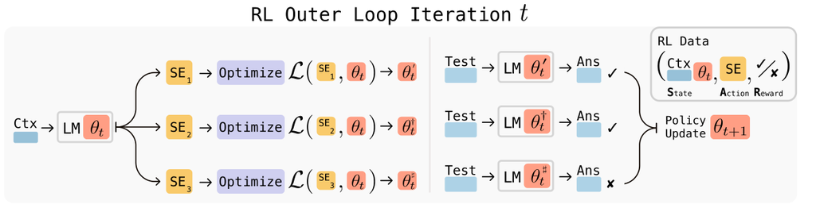

Original source · [Zweiger et al. · SEAL v2 · Figure 1, p. 2; caption omitted](https://arxiv.org/abs/2506.10943v2)

Learn to learn

Write text about a passage → train a model copy → test answers.

Test without the passage. Reward text that leads to better answers, teaching the model to prepare its own training data.

Figure key: Ctx = passage; LM = language model; SE = generated training text; θ = weights; ✓ / ✗ = answer feedback.

SELF-EVOLVING AGENTSRESULTS / DURABILITY

## SEAL improves answers about a newly learned passage

Test 1 · Learn each passage separately, then answer without it in the prompt · 200 passages, 974 questions

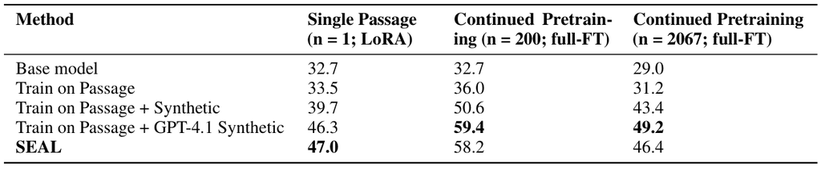

Original source · [Zweiger et al. · SEAL v2 · Table 2, p. 8 · Complete table](https://arxiv.org/abs/2506.10943v2)

+7.3 points

First numeric column: SEAL-written text 47.0%; original-model text 39.7%.

Both train on the passage plus generated text. GPT-4.1 text reaches 46.3% here and wins in the larger settings.

This tests learning new information. It does not test keeping it through later updates; that is the next experiment.

SELF-EVOLVING AGENTSRESULTS / DURABILITY

## SEAL’s earlier gains shrink as it learns more passages

Test 2 · Keep updating the same model on new passages, and re-test answers about earlier passages.

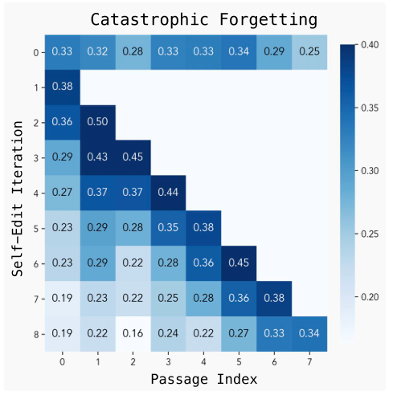

Original source · [Zweiger et al. · SEAL v2 · Figure 6, p. 8 · Complete heatmap; caption omitted](https://arxiv.org/abs/2506.10943v2)

### Follow the first column

Passage 0: 33% before learning → 38% just after learning it → 19% after all eight updates.

### What changed?

Later passages triggered more weight updates. Answers about the first passage became less accurate.

### Why SEAL belongs here

Learning new facts helped. Keeping those gains through further learning needed a separate test.

This SEAL recipe did not optimize retention. The result does not establish that all weight-update methods forget.

SELF-EVOLVING AGENTSRESULTS / DURABILITY

## Who tells a learning agent that it made a mistake?

### Shopify’s reported process

Find poorly rated conversations.  
Use stronger models to propose repairs.  
Replay and check the repairs.  
Train on accepted examples, old and new.

### Where correction comes from

Written quality criteria and judging models.  
Human help for unresolved cases.  
Then test whether the trained agent  
actually handles new conversations better.

Company-described design; the article does not measure each stage’s contribution or successive learning gains.

SELF-EVOLVING AGENTSRESULTS / IMPROVING THE IMPROVER

RESULTS / 03

## Can the agent improve how it proposes its next change?

So far, experience has changed instructions and training data. It might also improve the method used to propose future changes.

Hyperagents makes that method editable, then tests whether a developed system can improve on new work.

SELF-EVOLVING AGENTSRESULTS / IMPROVING THE IMPROVER

## Hyperagents can edit the code that proposes improvements

The system contains a task-solving agent and a second agent that proposes changes to it.

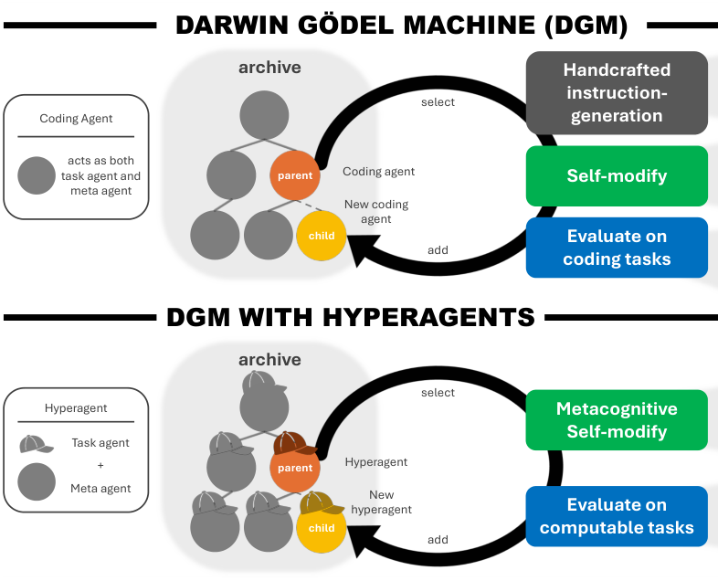

Original source · [Zhang et al. · Figure 1, p. 4 · Agent/archive loops; right-hand traces omitted](https://arxiv.org/abs/2603.19461v1)

### Task-solving code

The code that performs the work can change.

### Improvement code

The code that proposes edits can also change. This is the “meta-agent.”

### Test and keep candidates

The experiment still fixes how candidates are selected and evaluated.

Being able to edit the improvement method does not establish that the new method is better.

SELF-EVOLVING AGENTSRESULTS / IMPROVING THE IMPROVER

## A developed system makes useful progress on a new task

Hyperagents · transfer from paper review or robotics to grading math solutions; then allow 50 proposed changes

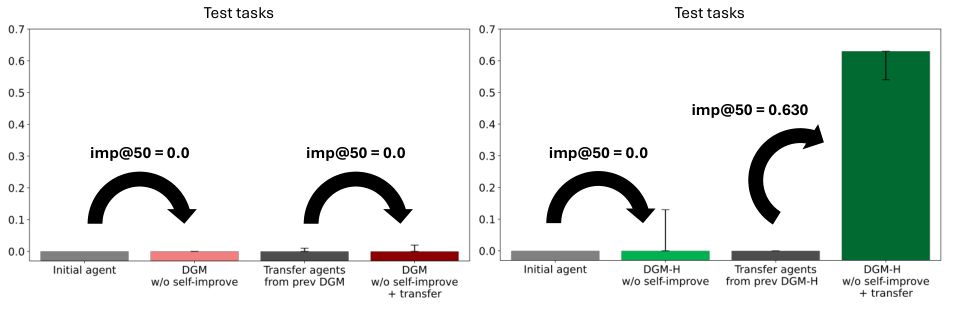

Original source · [Zhang et al. · Hyperagents v1 · Figure 3, p. 10 · Test panels; training panel omitted](https://arxiv.org/abs/2603.19461v1)

0.630 vs 0.000

Gain after 50 changes: 0.630 transferred versus 0.000 initial.

Fixed improvement method; five runs. Transferred 95% interval: 0.540–0.630.

The whole system transfers. This does not isolate its improvement code; the initial system also has formatting failures.

SELF-EVOLVING AGENTSCONCLUSION

## Learning is useful when a correction helps again

Our interpretation of the evidence: turn experience into checks that improve later work.

01

### Add something useful

Compare learned instructions with good instructions supplied upfront.

**FinEvo: 93.71 versus 86.67**

02

### Use it at the right time

Select relevant lessons and check that later learning preserves earlier abilities.

**AgentStream and SEAL show why**

03

### Justify the added work

Count learning and operating costs, then ask what the better outcomes are worth.

**More use alone does not ensure savings**

A saved correction is a promising mechanism. Sustained improvements and economic value still need to be measured.

SELF-EVOLVING AGENTSCONCLUSION

## Test whether the correction changes what happens next time

Proposed evaluation · compare agents on the same new work

| Question | Comparison | What to measure |
| --- | --- | --- |
| Does experience help? | Saved lessons vs reset vs expert instructions | Quality on the same new tasks |
| When does a lesson apply? | Related tasks vs different kinds of work | Benefit or harm from reusing it |
| What survives later learning? | Revisit old tasks after new updates | Earlier skills retained or lost |
| Is learning worth its cost? | Learning vs good instructions vs extra attempts | Better outcomes and all added costs |

Use repeated runs and independent evaluation. Test both saved changes and the ability to keep learning.

SELF-EVOLVING AGENTSCONCLUSION / DISCUSSION

## When would you choose to keep learning?

1. 01

### Would the extra quality justify the extra work?

   FinEvo: fixed instructions score 86.67; learned procedures 93.71, using about 3.9× the recorded tokens.
2. 02

### Which lesson should the agent use—or stop using?

   A saved check may be irrelevant, outdated, or lost during later learning. These need different remedies.
3. 03

### What would convince you a correction lasts?

   Name a future task, a comparison, and a result that would change your decision.

Choose a prediction, the evidence you would collect, and a result that would change your mind.

SELF-EVOLVING AGENTSAPPENDIX

## Appendix · continued evolution leaves an uncertain advantage

Hyperagents · endpoint score, not improvement@50 · 200 iterations with continued meta-level changes

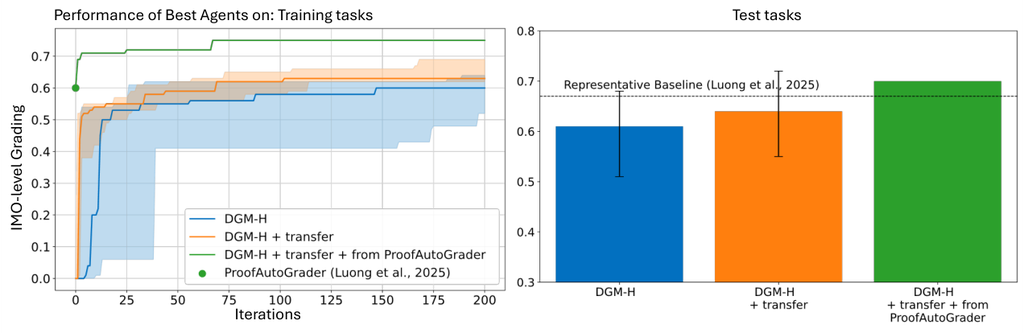

Original source · [Zhang et al. · Hyperagents v1 · Figure 4, p. 13 · Both panels](https://arxiv.org/abs/2603.19461v1)

0.640 vs 0.610

Compare orange (transfer) with blue (initial): 0.640 vs 0.610.

Five runs; p > .05. Green is a different ProofAutoGrader initialization, not the chosen contrast.

A nonsignificant difference is not proof of equivalence. Neither experiment shows sustained compounding.

SELF-EVOLVING AGENTSAPPENDIX

## Appendix · stream averages hide configuration differences

AgentStream · 3 models × 5 methods × 3 task orders = 45 cells per condition

| Task stream / retained state | Mean gain | Positive / negative / tie |
| --- | --- | --- |
| Isolated · separate state per benchmark | +1.37 pp | 34 / 11 / 0 |
| Sequential · carry state across domain blocks | +0.75 pp | 28 / 16 / 1 |
| Interleaved · mix domains, share one state | +0.90 pp | 28 / 17 / 0 |

**+0.90 pp** Interleaved gain over the same model with no retained state.

Stream definitions: §3.2 · Numbers calculated from Tables 2, 11–13

Each row reuses 300 tasks. Counts are descriptive, not independent datasets or a confidence interval.

SELF-EVOLVING AGENTSAPPENDIX

## Appendix · compare four practical alternatives fairly

Proposed experiment · same task stream, feedback access, and total resource ceiling

| Arm | What it can use | What it tests |
| --- | --- | --- |
| A Fixed expertise | Strong supplied procedure | What good initial guidance buys |
| B Fresh + attempts | Extra inference; no retained state | What extra attempts buy |
| C Fixed improver | Retained experience; fixed update rule | Learning under a fixed method |
| D Editable improver | Retained experience; editable update rule | Value of revising that method |

Match C and D’s initial task code, improvement code, and memory. Add a paired reset control.

SELF-EVOLVING AGENTSAPPENDIX

## Appendix · separate what it knows from what it can learn next

Proposed evaluation · separate frozen reuse from resumed adaptation

### Freeze and reuse

Test fresh cases and new families.  
Revisit earlier abilities.  
What has accumulated experience already made possible?

### Let copies learn again

Use fresh task streams.  
Compare the gains they produce.  
What has experience changed about future learning?

Isolate the improver: original vs learned method, both fixed, on identical task agents and memory.

SELF-EVOLVING AGENTSAPPENDIX

## Appendix · read each number with its denominator

Different tasks, metrics, and budgets prevent a pooled effect size.

| Evidence | Unit / repeated structure | Uncertainty limit |
| --- | --- | --- |
| WikiSkill | 5 benchmarks; 3 evolution runs | No numerical Table 1 CI |
| SEAL adaptation | 974 questions / 200 passages | No final-score repeat interval |
| SEAL retention | Sequential edits; revisit prior passages | Cell SEM; repeat count unclear |
| FinEvo | 120 tasks / 3 shuffled orders | No main-effect run intervals |
| Harness critique | 89 tasks; separate 34-task holdout | Two runs; no table CIs |
| AgentStream / Hyperagents | Shared-task cells / five runs | Seed SD / run-bootstrap CIs |

See the claim ledger for exact comparison limits and source-specific access depth.

SELF-EVOLVING AGENTSAPPENDIX

## Appendix · one-shot authoring is a different test

SkillsBench compares agents given curated skill packs, no skills, or one-shot self-authored skills.

### Curated skills help on average

Expert procedures are a meaningful baseline for an evolving agent.  
Benefits still vary across tasks.

### Self-authoring is one-shot here

Three tested configurations underperform no skills.  
No repeated outcome-feedback loop: this does not settle iterative learning.

SkillsBench v4: human curation cost and autonomous authoring effort are not matched.

SELF-EVOLVING AGENTSAPPENDIX

## Appendix · editing an agent and editing its improver differ

The important boundary is which learning decisions experience can change.

| System | What can change | What remains externally specified |
| --- | --- | --- |
| SICA | Agent implementation | Expand the best-scoring agent |
| DGM | Agent code; alternate lineages | Improvement-instruction generator |
| Hyperagents | Task code + improvement code | Outer archive and evaluation |

Edit permission makes a hypothesis testable. It does not establish that the edits help.

SELF-EVOLVING AGENTSAPPENDIX

## Appendix · primary sources 1/4

- **[Thrun · lifelong learning](https://www.ri.cmu.edu/pub_files/pub1/thrun_sebastian_1995_1/thrun_sebastian_1995_1.pdf)**1995 foundational work; introduction reviewed September 18https://www.ri.cmu.edu/pub_files/pub1/thrun_sebastian_1995_1/thrun_sebastian_1995_1.pdf · §§1–2
- **[GEM · continual learning](https://papers.neurips.cc/paper/2017/file/f87522788a2be2d171666752f97ddebb-Paper.pdf)**NeurIPS 2017; scoped foundation reviewhttps://papers.neurips.cc/paper/2017/file/f87522788a2be2d171666752f97ddebb-Paper.pdf · §§1–3: stability–plasticity, forward/backward transfer
- **[MAML · meta-learning](https://proceedings.mlr.press/v70/finn17a/finn17a.pdf)**ICML 2017; mechanism reviewed September 18https://proceedings.mlr.press/v70/finn17a/finn17a.pdf · §2; Algorithm 1
- **[Reflexion](https://arxiv.org/abs/2303.11366v4)**NeurIPS 2023; v4 reviewedhttps://arxiv.org/abs/2303.11366v4 · Algorithm 1; §§3–4
- **[Voyager](https://arxiv.org/abs/2305.16291v2)**Foundational 2023 workhttps://arxiv.org/abs/2305.16291v2 · §§2–3
- **[STOP](https://arxiv.org/abs/2310.02304v3)**2023 origin; v3 reviewedhttps://arxiv.org/abs/2310.02304v3 · Algorithm 1; §3

SELF-EVOLVING AGENTSAPPENDIX

## Appendix · primary sources 2/4

- **[GEPA](https://arxiv.org/abs/2507.19457v2)**2025 origin; v2 reviewedhttps://arxiv.org/abs/2507.19457v2 · Algorithm 1; §4
- **[WikiSkill](https://arxiv.org/abs/2608.27454v1)**Aug 27, 2026 preprint, v1https://arxiv.org/abs/2608.27454v1 · §3, Figure 2; Table 1; Appendix B
- **[Self-Adapting Language Models (SEAL)](https://arxiv.org/abs/2506.10943v2)**NeurIPS 2025; arXiv v2 reviewedhttps://arxiv.org/abs/2506.10943v2 · §3/Figure 1; Table 2; Appendix B; §5/Figure 6
- **[FinEvo-Bench](https://arxiv.org/html/2608.06144v1)**Aug 6, 2026 preprint, v1https://arxiv.org/html/2608.06144v1 · §§3–4; Table 5; Appendix C / Tables 25–27 / Figure 10
- **[Harness-evaluation critique](https://arxiv.org/abs/2607.12227v2)**2026 preprint; Aug 27 revision, v2https://arxiv.org/abs/2607.12227v2 · §§4.1–4.4; Tables 1–3
- **[AgentStream](https://arxiv.org/html/2608.00155v1)**Jul 31, 2026 preprint, v1https://arxiv.org/html/2608.00155v1 · §§3.1–3.2; Figures 1–2; Tables 2/5/6 and 11–13

SELF-EVOLVING AGENTSAPPENDIX

## Appendix · primary sources 3/4

- **[Hyperagents](https://arxiv.org/abs/2603.19461v1)**Mar 19, 2026 preprint, v1https://arxiv.org/abs/2603.19461v1 · §3/Figure 1; §5.2/Figure 3; §5.3/Figure 4
- **[Sidekick’s continual learning loop](https://shopify.engineering/sidekicks-continual-learning-loop)**Shopify Engineering, Aug 5, 2026; company reporthttps://shopify.engineering/sidekicks-continual-learning-loop · Harness optimization; trajectory repair; training; GraphQL sections
- **[SkillsBench](https://arxiv.org/abs/2602.12670v4)**Preprint; version as linked, reviewed September 16, 2026https://arxiv.org/abs/2602.12670v4 · Tables 2/6; Appendix D.6
- **[Darwin Gödel Machine](https://arxiv.org/abs/2505.22954v3)**ICLR 2026; v3 reviewedhttps://arxiv.org/abs/2505.22954v3 · §§2–4; Hyperagents §1/Appendix B for the boundary
- **[Self-Improving Coding Agent](https://arxiv.org/abs/2504.15228v2)**Preprint; version as linked, reviewed September 16, 2026https://arxiv.org/abs/2504.15228v2 · §3; Algorithm 1
- **[Gödel Machines](https://arxiv.org/abs/cs/0309048v5)**Foundational theory; v5 reviewedhttps://arxiv.org/abs/cs/0309048v5 · §§2.2/3.2/4.1

SELF-EVOLVING AGENTSAPPENDIX

## Appendix · primary sources 4/4

- **[Economics of RSI](https://arxiv.org/abs/2609.15802v1)**Preprint; version as linked, reviewed September 16, 2026https://arxiv.org/abs/2609.15802v1 · §§2–4; conditional model, not measured acceleration
- **[SkillOpt](https://arxiv.org/abs/2605.23904v2)**Preprint; version as linked, reviewed September 16, 2026https://arxiv.org/abs/2605.23904v2 · §§3.5–3.6; rejected edits retained as feedback
- **[ReasoningBank](https://arxiv.org/abs/2509.25140v2)**Preprint; version as linked, reviewed September 16, 2026https://arxiv.org/abs/2509.25140v2 · §§3–4; retained lessons plus test-time search
- **[Reward Hacking Benchmark](https://arxiv.org/abs/2605.02964v1)**Preprint; version as linked, reviewed September 16, 2026https://arxiv.org/abs/2605.02964v1 · §§4–6; evaluation integrity separate from task correctness
- **[Library Drift](https://arxiv.org/abs/2605.19576v3)**Preprint; version as linked, reviewed September 16, 2026https://arxiv.org/abs/2605.19576v3 · §§5–7; retrieval, storage, retirement
- **[EvoHarnessBench](https://arxiv.org/abs/2609.04280v2)**Preprint; version as linked, reviewed September 16, 2026https://arxiv.org/abs/2609.04280v2 · §§3–4; evolving tools, skills and specialist agents

SELF-EVOLVING AGENTSAPPENDIX

## Appendix · what work does FinEvo ask the agent to do?

120 tasks: 20 recurring kinds of financial work, six distinct cases each. The right panel shows a request and its input files.

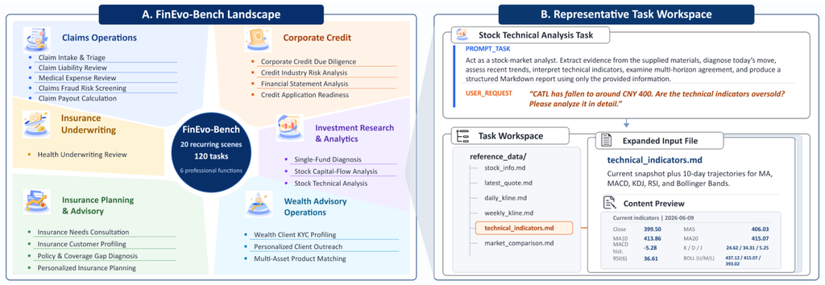

Original source · [Deng et al. · Figure 1, PDF p.3 · Full benchmark overview and example workspace; caption omitted](https://arxiv.org/html/2608.06144v1)